# Prognozowanie

Jakub Górowski, Dawid Ciochoń

1/19/2022

## Zadanie I - wybór i charakterystyka zbioru danych

Rozpatrywane dane to Australian retail trade turnover - miesięczny obrót w handlu w milionach australijskich dolarów (AUD). Wylosowany szereg dotyczy sprzedaży detalicznej artykułów elektrycznych i elektronicznych.

```r
set.seed(297954) #tu wstaw swój numer indeksu
myseries <- aus_retail %>%
  filter(`Series ID` == sample(aus_retail$`Series ID`,1))
kable(myseries ,caption = "Rozpatrywane dane")%>% kable_styling("striped") %>% scroll_box(width="100%",height="250px")
```

Rozpatrywane dane

| State | Industry | Series ID | Month | Turnover |
| --- | --- | --- | --- | --- |
| Northern Territory | Electrical and electronic goods retailing | A3349598V | 1988 kwi | 1.7 |
| Northern Territory | Electrical and electronic goods retailing | A3349598V | 1988 maj | 1.8 |
| Northern Territory | Electrical and electronic goods retailing | A3349598V | 1988 cze | 1.5 |
| Northern Territory | Electrical and electronic goods retailing | A3349598V | 1988 lip | 1.6 |
| Northern Territory | Electrical and electronic goods retailing | A3349598V | 1988 sie | 1.6 |
| Northern Territory | Electrical and electronic goods retailing | A3349598V | 1988 wrz | 1.8 |
| Northern Territory | Electrical and electronic goods retailing | A3349598V | 1988 paź | 1.8 |
| Northern Territory | Electrical and electronic goods retailing | A3349598V | 1988 lis | 1.8 |
| Northern Territory | Electrical and electronic goods retailing | A3349598V | 1988 gru | 2.8 |
| Northern Territory | Electrical and electronic goods retailing | A3349598V | 1989 sty | 1.8 |
| Northern Territory | Electrical and electronic goods retailing | A3349598V | 1989 lut | 1.6 |
| Northern Territory | Electrical and electronic goods retailing | A3349598V | 1989 mar | 2.1 |
| Northern Territory | Electrical and electronic goods retailing | A3349598V | 1989 kwi | 1.8 |
| Northern Territory | Electrical and electronic goods retailing | A3349598V | 1989 maj | 2.0 |
| Northern Territory | Electrical and electronic goods retailing | A3349598V | 1989 cze | 2.2 |
| Northern Territory | Electrical and electronic goods retailing | A3349598V | 1989 lip | 2.5 |
| Northern Territory | Electrical and electronic goods retailing | A3349598V | 1989 sie | 2.3 |
| Northern Territory | Electrical and electronic goods retailing | A3349598V | 1989 wrz | 2.6 |
| Northern Territory | Electrical and electronic goods retailing | A3349598V | 1989 paź | 2.6 |
| Northern Territory | Electrical and electronic goods retailing | A3349598V | 1989 lis | 2.6 |
| Northern Territory | Electrical and electronic goods retailing | A3349598V | 1989 gru | 3.9 |
| Northern Territory | Electrical and electronic goods retailing | A3349598V | 1990 sty | 2.1 |
| Northern Territory | Electrical and electronic goods retailing | A3349598V | 1990 lut | 2.0 |
| Northern Territory | Electrical and electronic goods retailing | A3349598V | 1990 mar | 2.4 |
| Northern Territory | Electrical and electronic goods retailing | A3349598V | 1990 kwi | 2.4 |
| Northern Territory | Electrical and electronic goods retailing | A3349598V | 1990 maj | 2.8 |
| Northern Territory | Electrical and electronic goods retailing | A3349598V | 1990 cze | 3.1 |
| Northern Territory | Electrical and electronic goods retailing | A3349598V | 1990 lip | 2.9 |
| Northern Territory | Electrical and electronic goods retailing | A3349598V | 1990 sie | 2.8 |
| Northern Territory | Electrical and electronic goods retailing | A3349598V | 1990 wrz | 3.0 |

[output cut: 339 more lines]

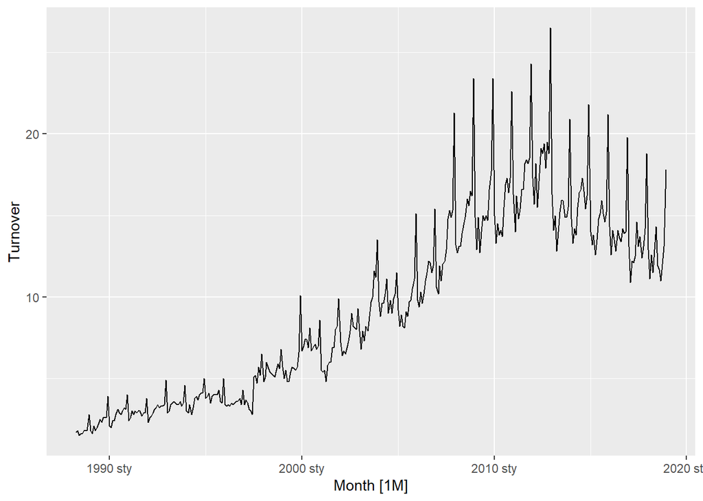

```r
myseries %>% autoplot(Turnover)
```

Szereg ten charakteryzuje się stale obecną sezonowością (wsytępują regularne *piki* wartości obrotu - istnieje miesiąc lub ich grupa w czasie których obrót znaczaco wzrasta w porównaniu do reszty roku).  
Przez większość rozpatrywanego okresu trend był rosnący - zjawisko to odwróciło się około roku 2013. Od tego czasu następuje systematyczny spadek obrotu (zatem trend jest malejący).  
W badanym zjawisku wyszczególniono również wahania cykliczne związane z cyklami koniunkturalnymi - w miarę coraz większego wzrostu gospodarczego i bogacenia się mieszkańców Australii następuje systematyczny wzrost wariancji (wartości sezonowe coraz bardziej wyróżniają się na tle kolejnych lat), natomiast po roku 2013 zauważyć można wygaszanie tego zjawiska - wysokości pików regularnie maleją.  
Warto zwrócić również uwagę na znaczący wzrost wartości obserwowanej zmiennej - na początku szeregu czasowego obrót artykułami elektronicznymi i elektrycznymi wynosił około 2 mln AUD, natomiast w szczytowym momencie było to aż około 27 mln AUD - zatem na przestrzeni 24 lat rynek ten zwiększył się prawie 14 razy.

## Zadanie II - Transformacja i dekompozycja

Z analizy wykresu zmiennej Turnover wynika, że przed dekompozycją szeregu czasowego konieczne będzie przetransformowanie danych, tak aby ustabilizować wariancję w czasie (jak zaznaczono powyżej, na przestrzeni około 80% długości szeregu czasowego występuje 14-krotna różnica w przyjmowanyc wartościach, w tym samym okresie cykliczność powoduje również bezwzględny wzrost wahań sezonowych z poziomu ok. 1 mln AUD do ponad 5 mln AUD). Proces transformacji danych dotyczy również innych przekształceń, natomiast nie ma potrzeby wykonywać ich dla rozpatrywanych danych - gdyż analizujemy jedynie ten konkretny szereg i nie porównujemy go np. z obrotem w innych krajach. Dla rozpatrywanego typu danych (dane z sektora handlu) rozpatrzeć można byłoby jeszcze miernik LFL (Like For Like). Jego wykorzystanie umożliwiłoby ocenę skuteczności punktów sprzedaży o ustablizowanej pozycji (do oblczeń przyjmuje się jedynie dane z punktów aktywnych od conajmniej roku lub dwóch lat). Natomiast ze względu na brak posiadania takich informacji ograniczono się do pierwszego z przykładów transformacji szeregu czasowego.

#### Stabilizacja wariancji

Postanowiono wykorzystaćnastępujace transformacje graniczne do usunięcia niestabilności wariancji:  
- Pierwiastek kwadratowy  
- Pierwiastek sześcienny  
- Logarytm naturalny  
- Odwrotność

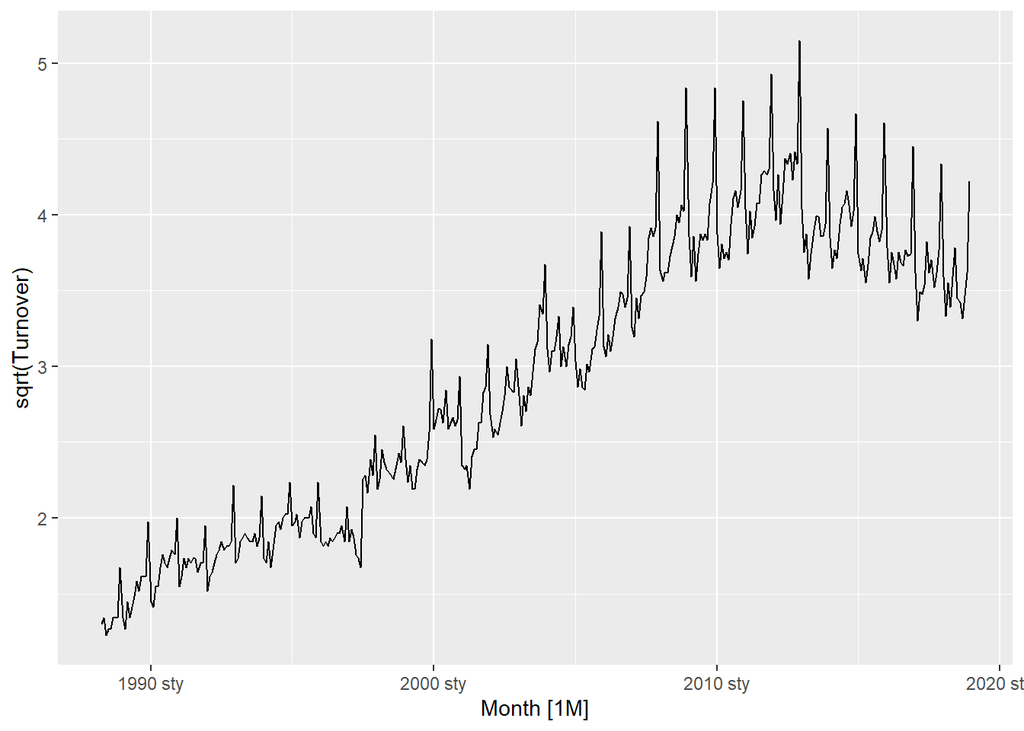

```r
myseries %>% autoplot(sqrt(Turnover))
```

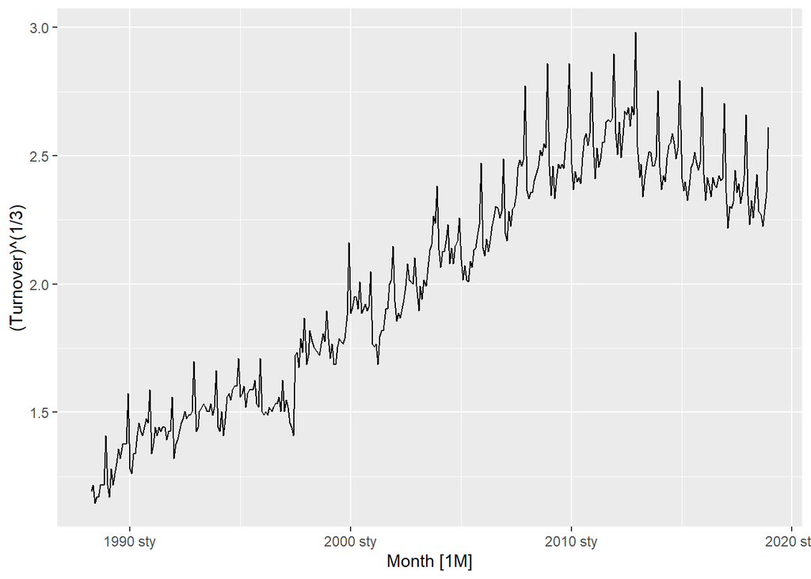

```r
myseries %>% autoplot((Turnover)^(1/3))
```

Zastosowanie zarówno pierwiastka kwadratowego, jak i sześciennego delikatnie zniwelowało różnice występujące w szeregu czasowym. Wciąż natomiast można zauważyć różnice w przebiegu szeregu w jego początkowej, jak i końcowej formie.

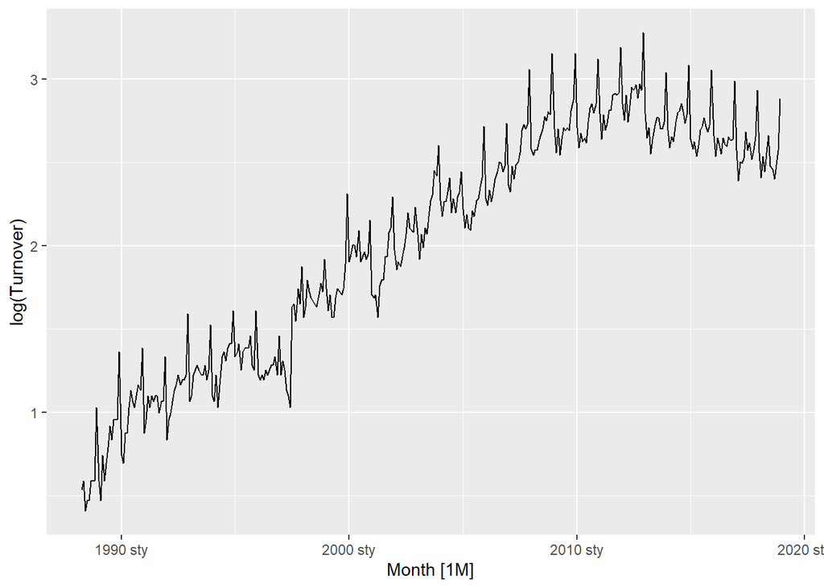

```r
myseries %>% autoplot(log(Turnover))
```

Wykorzystanie logarytmu zachowało sezonowość i trend, natomiast usunęło negatywny wpływ wahań cyklicznych - wahania sezonowe zostały ustabilizowane na podobnym poziomie, zachowano również zmianę trendu około roku 2013.

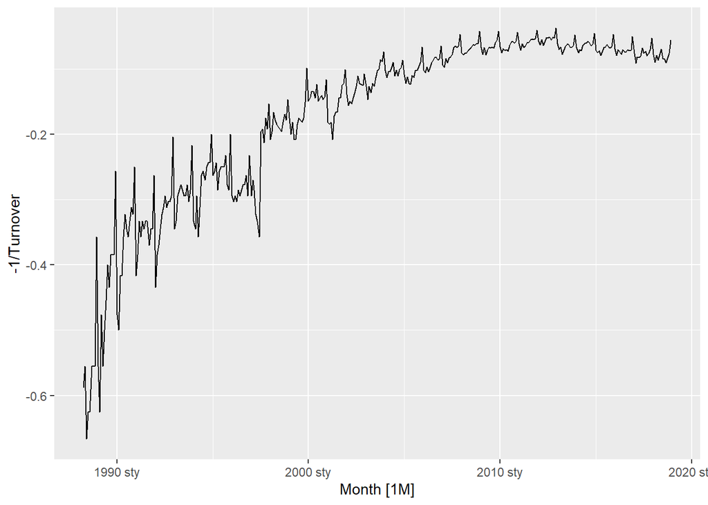

```r
myseries %>% autoplot(-1/Turnover)
```

Odwrócenie wartości nie okazało się skuteczną metodą, a wręcz przeciwnie - doprowadziło do znaczniejszego zwiększenia wariancji.  
Postanowiono sprawdzić również, jaka wartość *lambda* w przekształceniu Boxa-Coxa byłaby optymalna do rozpatrywanego szeregu czasowego. Poprawnie wybrana lambda sprawiłaby, że w przekształconym szeregu wariancja dla całego jego przekroju byłaby jednakowa. Metoda jej wyboru zaimplementowana w R bazyje na metodzie opracowanej przez V. M. Guerrerro.

```r
myseries %>% features(Turnover, features = guerrero)
```

```
## # A tibble: 1 x 3
##   State              Industry                                  lambda_guerrero
##   <chr>              <chr>                                               <dbl>
## 1 Northern Territory Electrical and electronic goods retailing          0.0442
```

Zalecana przez metodę Guerrero lambda przekształcenia Boxa-Coxa to 0.0442. Ze względu na utratę moliwości interpretacyjnych wynikających z zastosowania przekształcenia Boxa-Coxa, a takze na skuteczność przekształcenia z wykorzystaniem logarytmu, postanowiono pozostać przy tej bardziej intuicyjnej metodzie.

#### Analiza sezonowości

Pozostając jeszcze przy oryginalnych danych postanowiono szczegółowo przyjrzeć się sezonowości szeregu czasowego. W tym celu wykorzystano funkcje *gg_subseries* oraz *gg_season*. Analiza otrzyamnych wykresów umożliwia również lepsze zrozumienie procesów kształtujących wartośici Turnover.

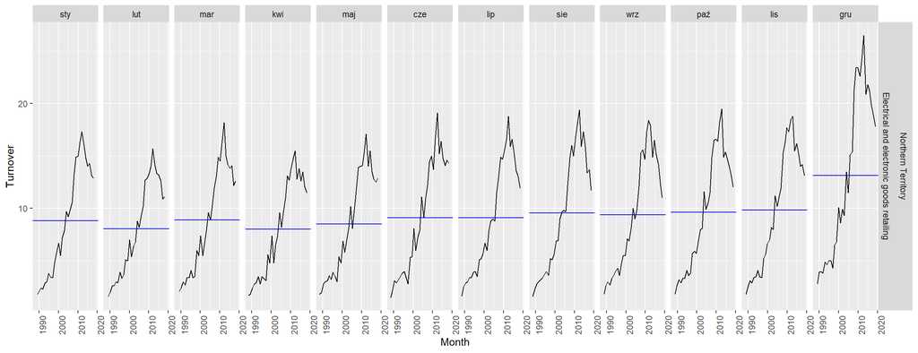

```r
myseries %>% gg_subseries(Turnover)
```

Na podstawie wykresu szeregów w kązdym z sezonów zauważyć można następujące wnioski:  
- W miesiącu następuje grudniu znaczny wzrost obrotu (zrozumiałe przez Święta Bożego Narodzenia, a także Mikołajki)  
- Z roku na rok ludzie kupują więcej elektroniki - związane może być to z poprawą poziomu życia i rozwojem  
- W latach 2012/2013 nastąpił znaczny spadek obrotu - jest to o tyle niezwykłe, ponieważ GFC (globany kryzys finansowy związany z pochodnymi instrumentami finanswymi) miał swoje apogeum w latach 2007-2009, zatem to w tym okresie (i latach bezpośrednio po nim) powinien nastąpić największy spadek zakupów elektroniki użytkowej (którą można postrzegać, jako dobro niekonieczne najistotniejsze dobro). Istnieje możliwość, że następstwa kryzysu dotarły do Australii z opóźnieniem. Według Wikipedii wikipedii dynamika PKB austalii była dodatnia w 2009 co potwierdza tezę o opóźnieniu wpływu kryzysu na Australię. Pogląd ten dodatkowo potwierdza [artykuł](https://www.rba.gov.au/education/resources/explainers/the-global-financial-crisis.html)

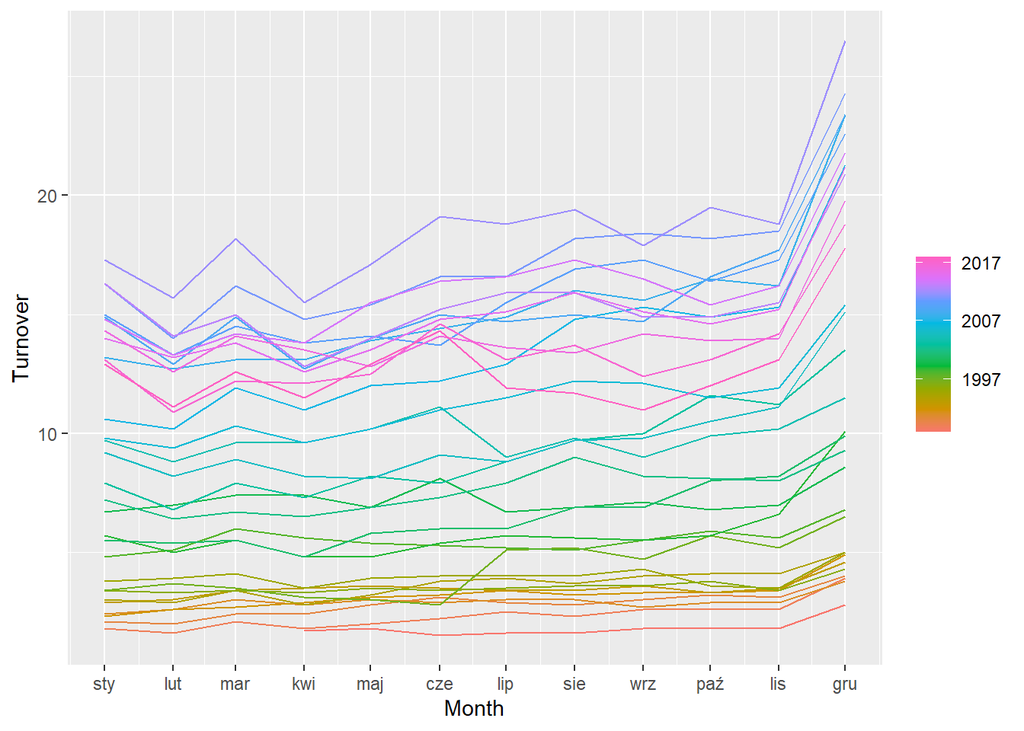

```r
myseries %>% gg_season(Turnover)
```

Analiza wykresu wyszczególniającego poszczególne lata na tle sezonów prowadzi do następujących wniosków:  
- Przy wyłączenia grudnia średni obrót w roku wzrósł z około 2-2,5 mln (pod koniec lat 80.) do około 15 mln w połoie II dekady XXI wieku  
- W miarę upływu lat wahania sezonowe dotyczące grudnia zwiększały się

W szczególności drugi z powyższych wniosków będzie istotny dla obecnego etapu badań, kończącego się dekompozycją szeregu czasowego. Bowiem sytuacja w której wahanie sezonowe coraz bardziej wzrasta w miarę upływu lat nie musi wiązać się z wahaniami cyklicznymi (tak jak zauważono wcześniej). Bowiem zjawisko proporcjonalności sezonowoości do poziomu szeregu czasowego wskazuje ono na zależność multiplikatywną w modelu. Zatem to nie wahania cykliczne, a multyplikatywny charakter procesu skutkują wzrostem wahań sezonowych.

#### Dekompozycja danych metodą STL

```r
myseries %>% model(classical_decomposition(log(Turnover), type="multiplicative")) %>% components() -> cldc
```

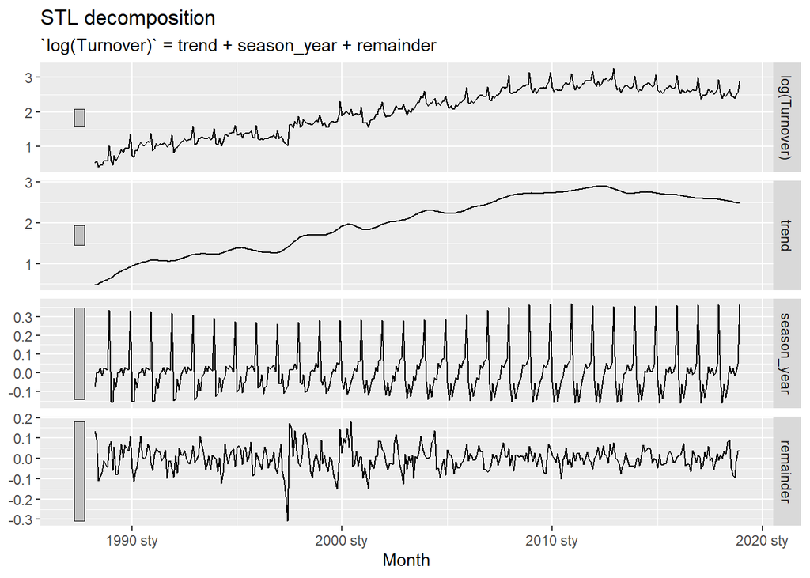

```r
myseries %>% model(STL(log(Turnover))) %>% components() -> cldc_stl
cldc_stl %>% autoplot()
```

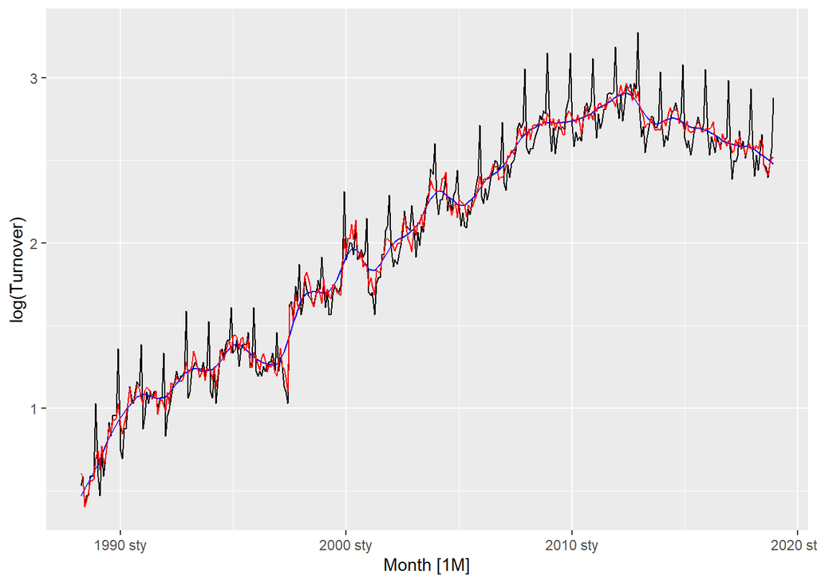

```r
myseries %>% autoplot(log(Turnover)) + autolayer(cldc_stl, trend, color="blue") + autolayer(cldc_stl,season_adjust, color="red")
```

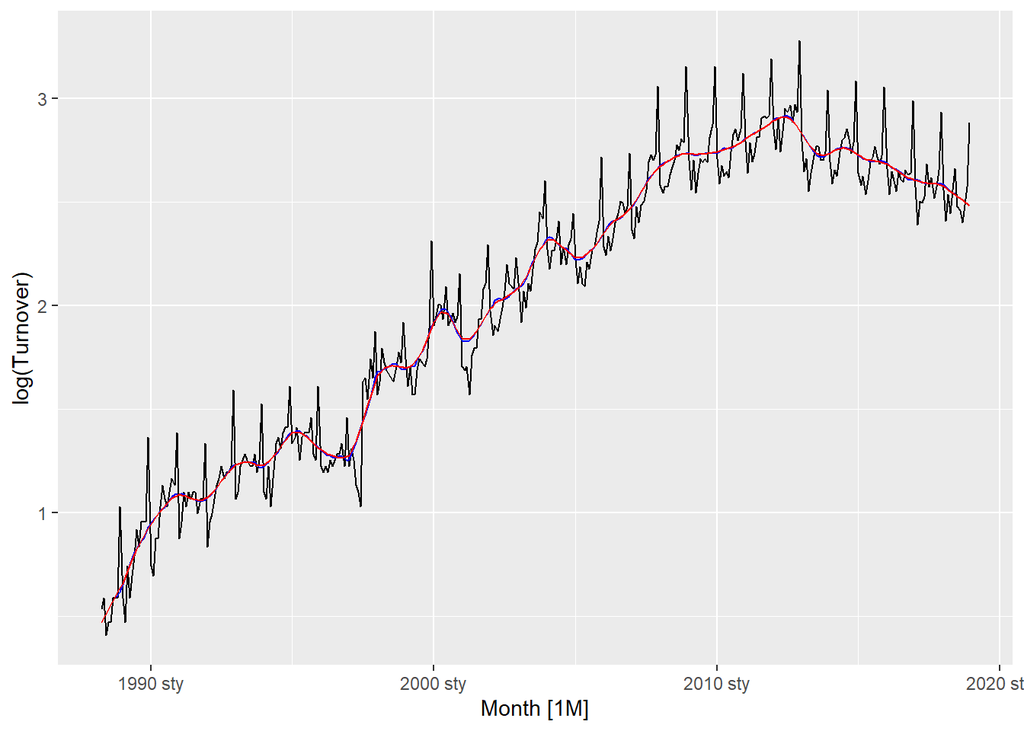

```r
myseries %>% autoplot(log(Turnover)) + autolayer(cldc, trend, color="blue") + autolayer(cldc_stl, trend, color = "red")
```

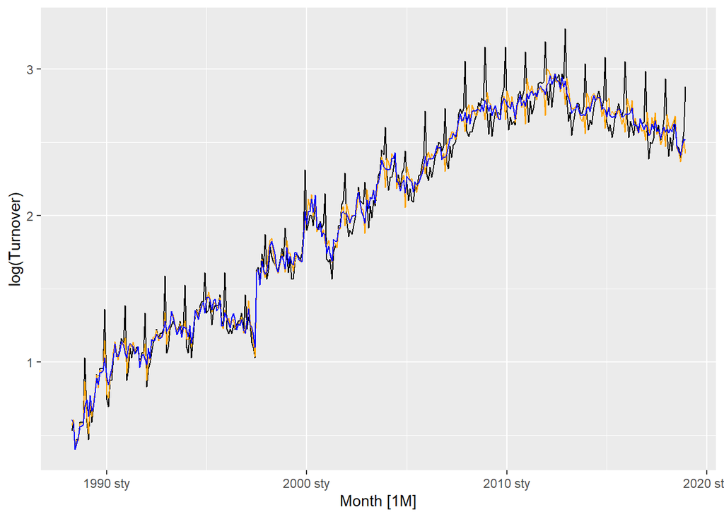

```r
myseries %>% autoplot(log(Turnover)) + autolayer(cldc, season_adjust, color="orange") + autolayer(cldc_stl,season_adjust, color="blue")
```

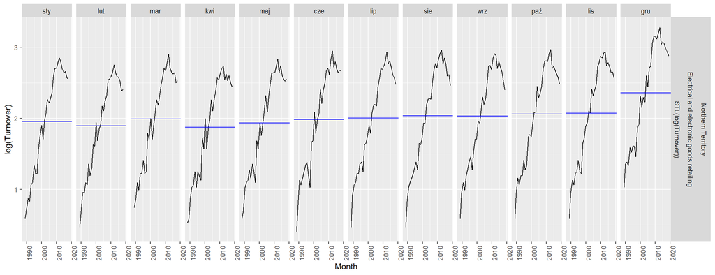

```r
cldc_stl %>% gg_subseries()
```

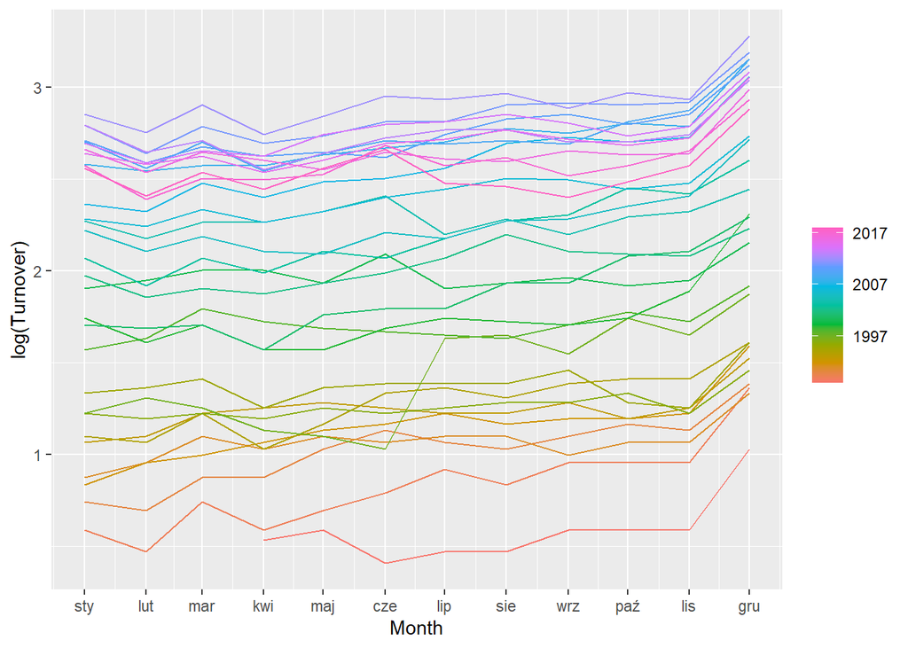

```r
cldc_stl %>% gg_season()
```

Ostatnim wykresami w tej części projektu ponownie są zestawienia dotyczące analizy sezonowości. Przygotowano natomiast w oparciu o przekształconą zmienną (log(Turnover)). Zastosowanie logarytmu poskutkowało:  
- wyrównaniem i zbliżeniem do siebie przebiegu szeregów czasowych dla miesięcy styczeń-listopad (ich wykresy są podobne, a ich wartości maksymalne są na tym samym poziomie) - zmniejszeniem róznicy pomiędzy grudniem, a resztą roku (zauważyć można zmniejszenie rozpiętości wykresu dla ostatniego miesiąca roku) - wartości średnie reprezentowane niebieską linią pozostały w taki msamym układzie, pomimo przedstawionych pwoyżej zmian (zatem zlogarytmowanie nie wpłynęło na zależności średnich między sobą) - zwiększyłą się amplituda skrajnych wartości dla szeregów początkowych lat (ze względu na znaczną rozpiętość skali lata te wydawały się bardzo zbliżone i wypłaszczone na wykresie zmiennej Turnover) - wpływ miesiąca grudnia został uśredniony (skrajnie duże wartości z końca szeregu oraz niewielkie wzrosty w początkowych latach zostały uśrednione - z wykresu dla log(Turnover) odczytać mozna, że wpływ grudnia na przestrzeni lat nie zmieniał się)

Zatem zastosowanie logarytmu przyniosło wiele pozytywnych skutków - nie tylko ustbilizowano wahania sezonowe, lecz również ułatwiono interpretację poszczególnych wycinków rocznych szeregu czasowego (a to wszystko przy zachowaniu proporcji średnich z poszczególnych miesięcy)

## Zadanie III - Proste prognozy

Dane projektowe zostały podzielone na zbiór treningowy (dane do 2011 roku) oraz zbiór testowy (dane od 2012 roku). Zbiór testowy zawiera 84 obserwacje, natomiast zbiór treningowy 285 obserwacji. Poniższy wykres przedstawia podział na zbiór testowy oraz treningowy:

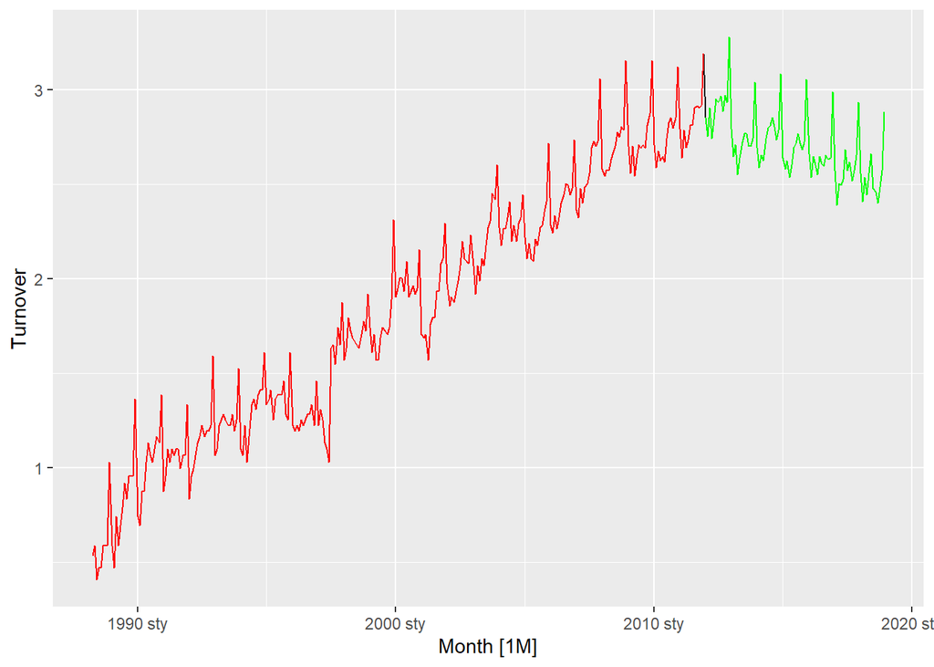

```r
myseries %>% filter(year(Month)<=2011) ->train
myseries %>% filter(year(Month)>2011) ->test

train_log<-train
train_log$Turnover<-log(train$Turnover)
test_log<-test
test_log$Turnover<-log(test$Turnover)
myseries_log <- myseries
myseries_log$Turnover <- log(myseries$Turnover)

autoplot(myseries_log) +
  autolayer(train_log, series="Training", color='red') +
  autolayer(test_log, series="Test", color='green')
```

```r
#Prognoza metodami benchmarkingowymi
train %>% select(Turnover) %>% model(mean = MEAN(log(Turnover)),
                naive = NAIVE(log(Turnover)),
                snaive = SNAIVE(log(Turnover) ~ lag(12)),
                drift = RW(log(Turnover) ~drift())
                #agre = (SNAIVE(log(Turnover))/2 + RW(log(Turnover) ~drift())/2)
) -> train_fit
train_fit %>% forecast(h=nrow(test)) -> myseries_fc#%>% autoplot(level=NULL) +autolayer(train)
```

```r
acc_train <- accuracy(train_fit)
acc_train %>%
  kbl(booktabs = T) %>%
  kable_styling(bootstrap_options = c("striped", "hover", "responsive",'bordered'))
```

| .model | .type | ME | RMSE | MAE | MPE | MAPE | MASE | RMSSE | ACF1 |
| --- | --- | --- | --- | --- | --- | --- | --- | --- | --- |
| mean | Training | 1.5048269 | 5.238060 | 4.0430480 | -24.5497855 | 65.66525 | 3.9846646 | 3.875306 | 0.9265602 |
| naive | Training | 0.0795775 | 1.615680 | 0.8894366 | -0.4829167 | 11.59379 | 0.8765928 | 1.195339 | -0.3211704 |
| snaive | Training | 0.6798535 | 1.351651 | 1.0146520 | 8.1872064 | 13.97884 | 1.0000000 | 1.000000 | 0.7347719 |
| drift | Training | 0.0080409 | 1.619501 | 0.8824556 | -1.4284265 | 11.60349 | 0.8697125 | 1.198165 | -0.3229753 |

Analizując wyniki dopasowania modeli na zbiorze treningowym, można zauważyć, że najmniejszym błędem opatrzone są wartości otrzymane z modelu wykonanego metodą naiwną - błąd MAPE wynosi 11,59%. Jednak niewiele gorsza wydaje się metoda dryfu - błąd MAPE w przybliżeniu równy 11,60%.

```r
acc_test <- accuracy(myseries_fc, test)
acc_test %>%
  kbl() %>%
  kable_styling(bootstrap_options = c("striped", "hover", "bordered", "responsive"))
```

| .model | .type | ME | RMSE | MAE | MPE | MAPE | MASE | RMSSE | ACF1 |
| --- | --- | --- | --- | --- | --- | --- | --- | --- | --- |
| drift | Test | -51.304136 | 60.739098 | 51.304136 | -374.11692 | 374.11692 | NaN | NaN | 0.9622376 |
| mean | Test | 7.477841 | 7.962493 | 7.477841 | 48.23917 | 48.23917 | NaN | NaN | 0.4589440 |
| naive | Test | -23.299019 | 25.267957 | 23.299019 | -167.64276 | 167.64276 | NaN | NaN | 0.9345562 |
| snaive | Test | -3.533805 | 4.480897 | 3.851059 | -25.74376 | 27.43484 | NaN | NaN | 0.8747276 |

Przechodząc do analizy dopasowania prognoz dla okresu testowego, najmniejszą wartość błędu MAPE można zaobserwować przy prognozie metodą naiwną z uwzględnieniem sezonowości (SNAIVE). Pozostałe metody obarczone są zdecydowanie większymi błędami. Na podstawie powyższych wniosków najlepej dopasowane wartości zostały otrzymane dzięki zastosowaniu metody snaive, co oznacza, że model ten działa bardzo dobrze na nowych danych, nie wykorzystanych do jego wyuczenia. Dlatego też analiza reszt zostanie przeprowadzona dla reszt z tego właśnie modelu.

Zanim jednak zostanie przeprowadzona analiza reszt, warto przyjrzeć się poniższym wykresom, na których zostały przedstawione prognozy otrzymane za pomocą wszystkich modeli.

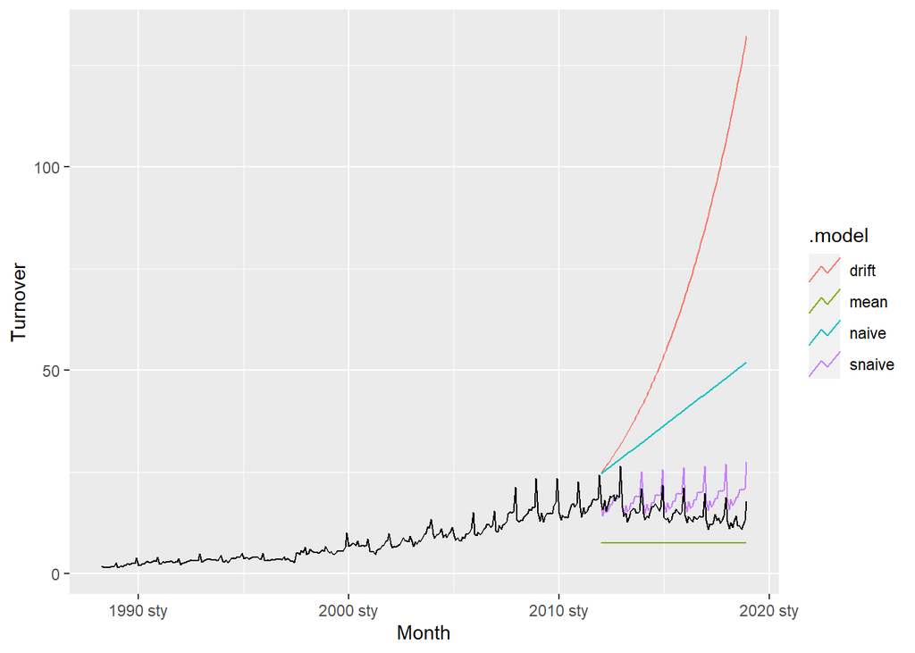

```r
myseries_fc %>% autoplot(level=NULL) +autolayer(myseries, Turnover, color='black')
```

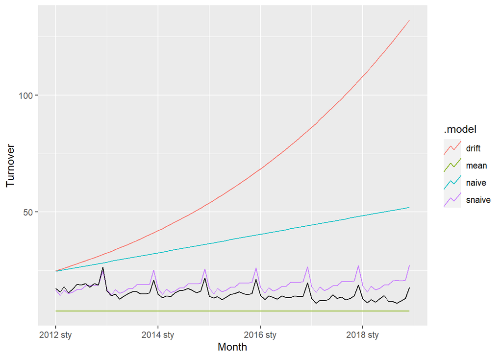

```r
train_fit %>% forecast(h=nrow(test)) %>% autoplot(level=NULL) +autolayer(test, color='black')
```

Powyżej przedstawiono jedynie prognozy wraz z obserwacjami testowymi. Można tu dostrzec, że krzywa obrazująca kształtowanie się prognoz na podstawie metody SNAIVE jest praktycznie odwzorowaniem krzywej z wartościami rzeczywistymi, przesuniętym wzdłuż osi Y. Krzywa przedstawiająca prognozy dla metody średniej nie uwzględnia ani trendu ani cykliczności, natomiast dla pozostałych dwóch krzywych można zauważyć jedynie trend wzrostowy.

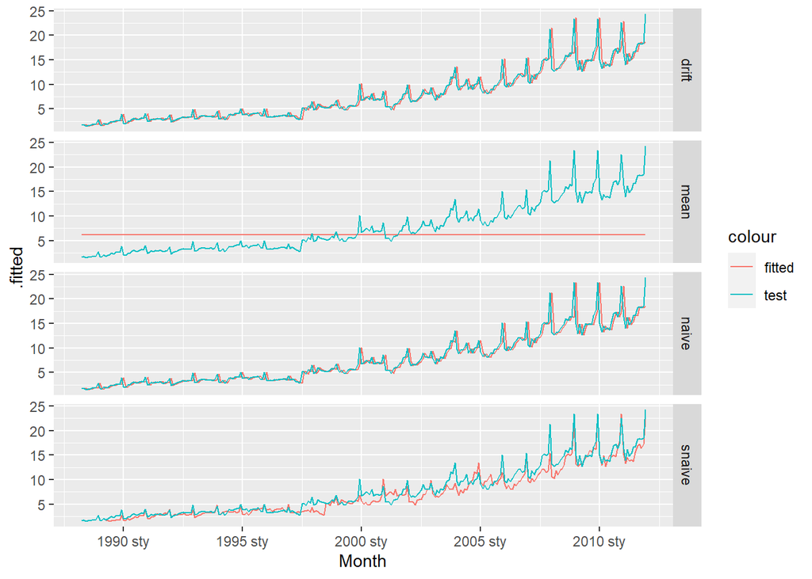

```r
ggplot(augment(train_fit), aes(x = Month, y = .fitted, colour='fitted')) +
  geom_line() +
  geom_line(aes(y=Turnover, colour='test')) +
  facet_grid(rows = vars(.model)) #+
```

Jak już wcześniej zaznaczono, na podstawie błędów prognoz, najlepszym modelem okazał się model naiwny uwzględniający sezononwość. Dla tego modelu przeprowadzono więc analizę reszt, sprawdzając, czy posiadają rozkład normalny oraz czy występuje w nich autokorelacja.

Wykres reszt przestawiono poniżej:

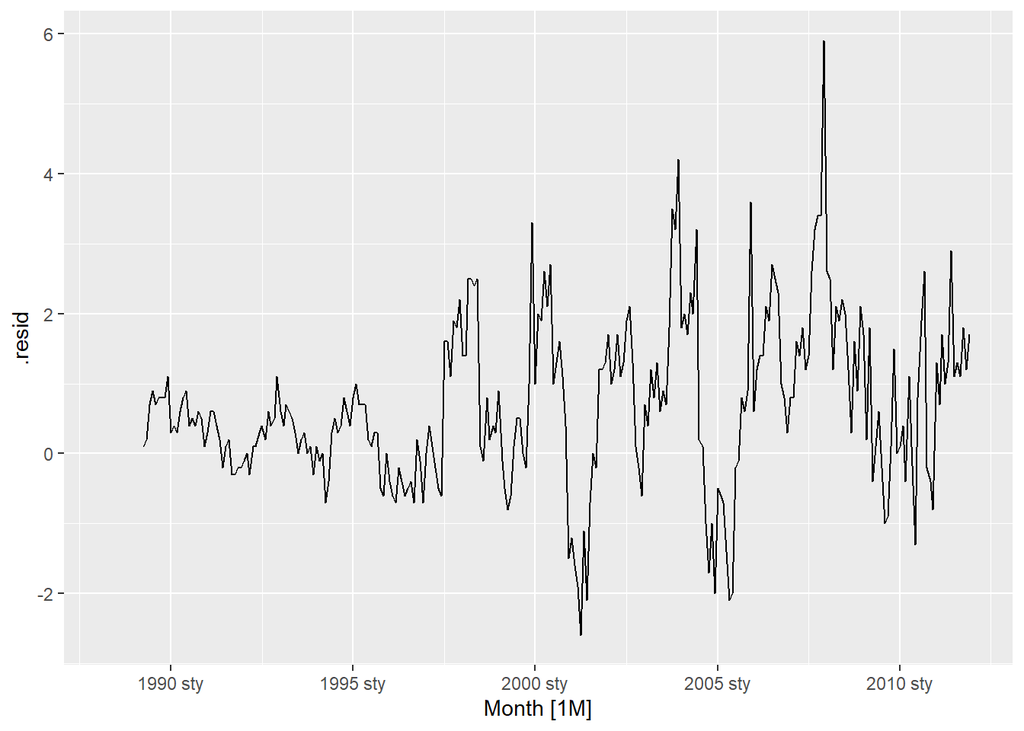

```r
train %>% select(Turnover) %>% model(
                snaive = SNAIVE(log(Turnover) ~ lag(12)),
) -> snaive_fit

augment(snaive_fit) -> aug_snaive

#aug_snaive %>% autoplot(Turnover) + autolayer(aug_snaive, .fitted, color = "Red") #warto?? dopasowna plus rzeczywista
aug_snaive %>% autoplot(.resid) #reszty
```

Można zauważyć, że wariancja reszt nie jest stała, natomiast średnia jest większa niż zero, co sprawia, że prognoza może nie być prawdziwa.

Histogram dla reszt wraz z wykresem gęstości:

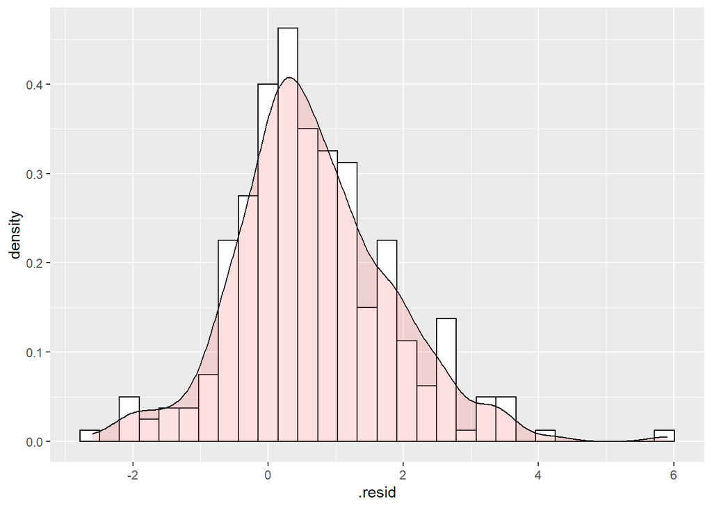

```r
aug_snaive %>% ggplot(aes(x=.resid))+geom_histogram(aes(y=..density..),colour="black", fill="white")+
  geom_density(alpha=.2, fill= "#FF6666")# histogram
```

Kształt powyższego wykresu pozwala sądzić, że rozkład reszt jest zbliżony do rozkładu normalnego, jednak dłuższy prawy ogon może zaburzyć rozkład, dlatego też w celu potwierdzenia tego przypuszczenia został wykonany test Shapiro-Wilka na normalność rozkładu. W teście tym hipotezy mają postać:

H_0: Rozlkład normalny  
H_1: Brak rozkładu normalnego

```r
shapiro.test(aug_snaive$.resid)
```

```
##
##  Shapiro-Wilk normality test
##
## data:  aug_snaive$.resid
## W = 0.97847, p-value = 0.0003843
```

P-value otrzymane z testu jest zdecydowanie mniejsze niż poziom istotności wynoszący 5%, więc należy odrzucić hipotezę zerową i uznać, że reszty nie mają rozkładu normalnego.

Chociaż reszty nie spełniają podstawowych założeń taki jak normalność rozkładu oraz wykres zbliżony do białego szumu, została zbadana dodatkowo autokorelacja:

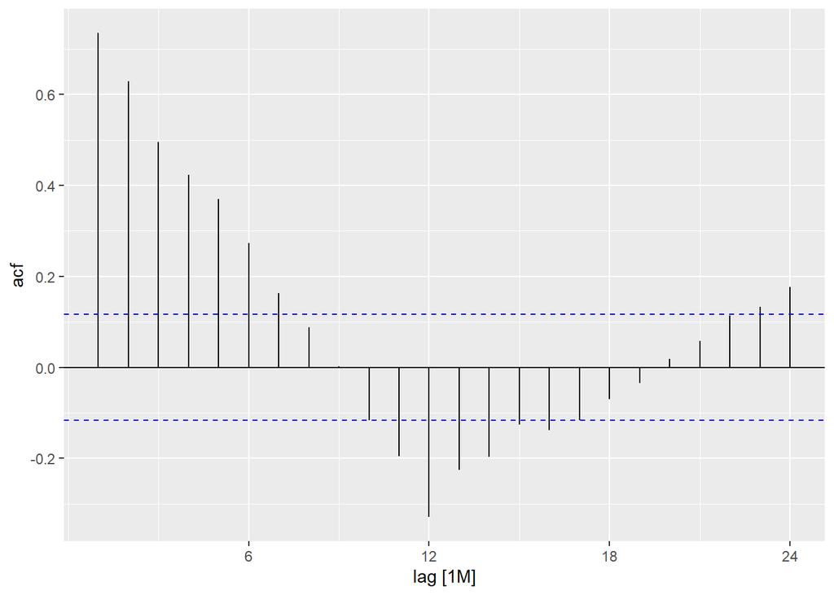

```r
aug_snaive %>% ACF(.resid) %>% autoplot()
```

W resztach występuje autokorelacja aż do opóźnienia równego 7, następnie chwilowo zanika i znowu ma miejsce. Wygląda to tak, jakby uwidaczniała się tu sezonowość.

## Zadanie IV - ETS

W kolejnym kroku zbudowano model multiplikatywny Holta-Wintersa z trendem wygaszonym oraz niewygaszonym, a następnie porównano oba modele ze sobą.

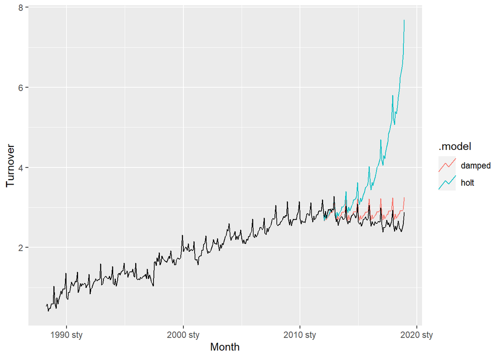

```r
fit_holt <- train_log %>% select(Turnover) %>%
  model(
    holt = ETS(Turnover ~ error("M") + trend("M") + season("M")),
    damped = ETS(Turnover ~ error("M") + trend("Md") + season("M")),
  )

fit_holt %>% forecast(h = nrow(test)) -> holt_fc
#holt_fc %>%
holt_fc %>% autoplot(level=NULL) + autolayer(myseries, log(Turnover), color='black')
```

Na podstawie powyższego wykresu można wysnuć wniosek, iż prognoza metodą Holta-Wintersa z wygaszonym trendem zdecydowanie lepiej nadaje się do prognozowania analizowanych danych, gdyż otrzymane wartości prognozy są zbliżone do wartości rzeczywistych. Natomiast metoda Holta-Wintersa z niewygaszonym trendem uwzględnia fakt, że do pewnego momentu faktycznie w danych można dostrzec trend wzrostowy, jednak gdy trend zanika metoda ta nie potrafi przewidzieć takiego zachowania.

Poniżej zaprezentowano wartoci błędów otrzymane dla danych treningowych:

```r
## parametry modelu
#tidy(fit_holt)
holt_acc_train <- accuracy(fit_holt)
holt_acc_train %>%
  kbl() %>%
  kable_styling(bootstrap_options = c("striped", "hover", "bordered", "responsive"))
```

| .model | .type | ME | RMSE | MAE | MPE | MAPE | MASE | RMSSE | ACF1 |
| --- | --- | --- | --- | --- | --- | --- | --- | --- | --- |
| holt | Training | -0.0114991 | 0.1058695 | 0.0771351 | -1.3149469 | 5.424548 | 0.5073624 | 0.5487210 | 0.3410550 |
| damped | Training | 0.0006624 | 0.0977796 | 0.0713974 | -0.3739238 | 4.782880 | 0.4696223 | 0.5067912 | 0.1609946 |

Porównując błędy RMSE oba modele dają zbliżone rezultaty, dlatego przeanalizowano również błędy otrzymane na danych testowych:

```r
holt_acc_test <- accuracy(holt_fc, test_log)
holt_acc_test %>%
  kbl() %>%
  kable_styling(bootstrap_options = c("striped", "hover", "bordered", "responsive"))
```

| .model | .type | ME | RMSE | MAE | MPE | MAPE | MASE | RMSSE | ACF1 |
| --- | --- | --- | --- | --- | --- | --- | --- | --- | --- |
| damped | Test | -0.1544718 | 0.2100351 | 0.1784139 | -5.963638 | 6.783834 | NaN | NaN | 0.8931470 |
| holt | Test | -1.1439658 | 1.6576826 | 1.1586612 | -44.020711 | 44.529045 | NaN | NaN | 0.9333387 |

W tym przypadku już model z wygaszonych trendem okazał się zdecydowanie lepszy, gdyż błąd prognozy RMSE jest dla wspomnianego modelu ponad siedmiokrotnie niższy niż dla modelu z trendem.

Wykres reszt z modelu Holta-Wintersa z wygaszonym trendem ma postać:

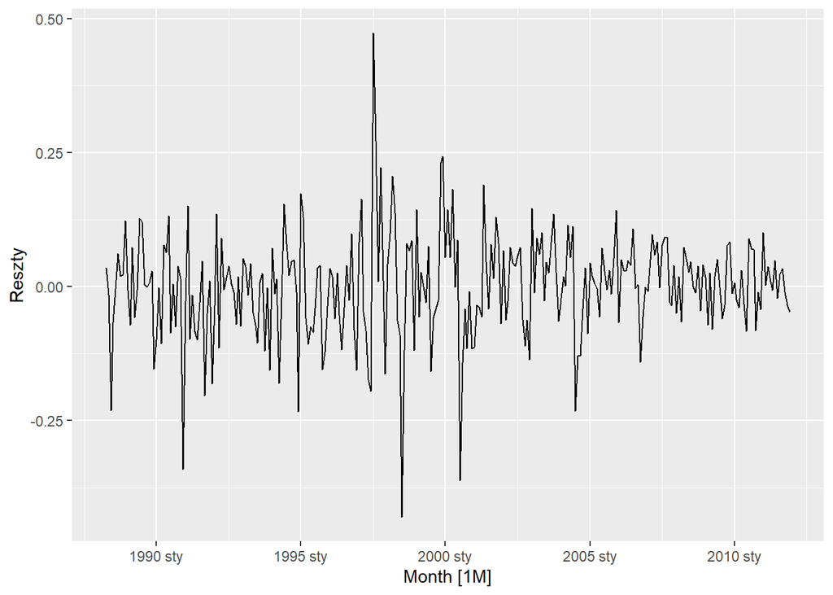

```r
fit_holt_damped <- train_log %>% select(Turnover) %>%
  model(
    damped = ETS(Turnover ~ error("M") + trend("Md") + season("M"))
  )

augment(fit_holt_damped) %>% autoplot(.resid) +
  ylab('Reszty')
```

Reszty wybranej prognozy przypominają biały szum, gdyż oscylują wokół zera, natomiast wariancja, poza kilkoma większymi przypadkami, może byc traktowana jako stała.

Mając wybraną najlepszą prognozę otrzymaną metodami benchmarkingowymi oraz lepszy z modeli Holta-Wintersa można zestawić je ze sobą w celu porównania otrzymanych wyników.

```r
damped_train <- holt_acc_train[holt_acc_train$.model == 'damped',]
snaive_train <- acc_train[acc_train$.model == 'snaive',]

kbl(rbind(damped_train, snaive_train)) %>%
  kable_styling(bootstrap_options = c("striped", "hover", "bordered", "responsive"))
```

| .model | .type | ME | RMSE | MAE | MPE | MAPE | MASE | RMSSE | ACF1 |
| --- | --- | --- | --- | --- | --- | --- | --- | --- | --- |
| damped | Training | 0.0006624 | 0.0977796 | 0.0713974 | -0.3739238 | 4.78288 | 0.4696223 | 0.5067912 | 0.1609946 |
| snaive | Training | 0.6798535 | 1.3516507 | 1.0146520 | 8.1872064 | 13.97884 | 1.0000000 | 1.0000000 | 0.7347719 |

Na podstawie wartości błędów otrzymanych dla danych treningowych można uznać, że model Holta-Wintersa z wygaszonym trendem jest lepszym modelem niż prognoza naiwna. Jednak bardziej interesujące jest czy dla danych, na których model nie został wyuczony również otrzyma się lepsze wyniki prognozy.

```r
damped_test <- holt_acc_test[holt_acc_test$.model == 'damped',]
snaive_test <- acc_test[acc_test$.model == 'snaive',]

kbl(rbind(damped_test, snaive_test)) %>%
  kable_styling(bootstrap_options = c("striped", "hover", "bordered", "responsive"))
```

| .model | .type | ME | RMSE | MAE | MPE | MAPE | MASE | RMSSE | ACF1 |
| --- | --- | --- | --- | --- | --- | --- | --- | --- | --- |
| damped | Test | -0.1544718 | 0.2100351 | 0.1784139 | -5.963638 | 6.783834 | NaN | NaN | 0.8931470 |
| snaive | Test | -3.5338051 | 4.4808974 | 3.8510593 | -25.743759 | 27.434843 | NaN | NaN | 0.8747276 |

W tym przypadku wartości błędów prognoz również są lepsze dla modelu Holta-Wintersa. Można więc uznać, że model ten dla analizowanych danych jest modelem lepiej dopasowanym.

W kolejnym kroku podjęto próbę polepszenia prognozy poprzez zastosowanie dekompozycji STL oraz modelu ETS do danych skorygowanych sezonowo i przekształconych metodą Boxa-Coxa.

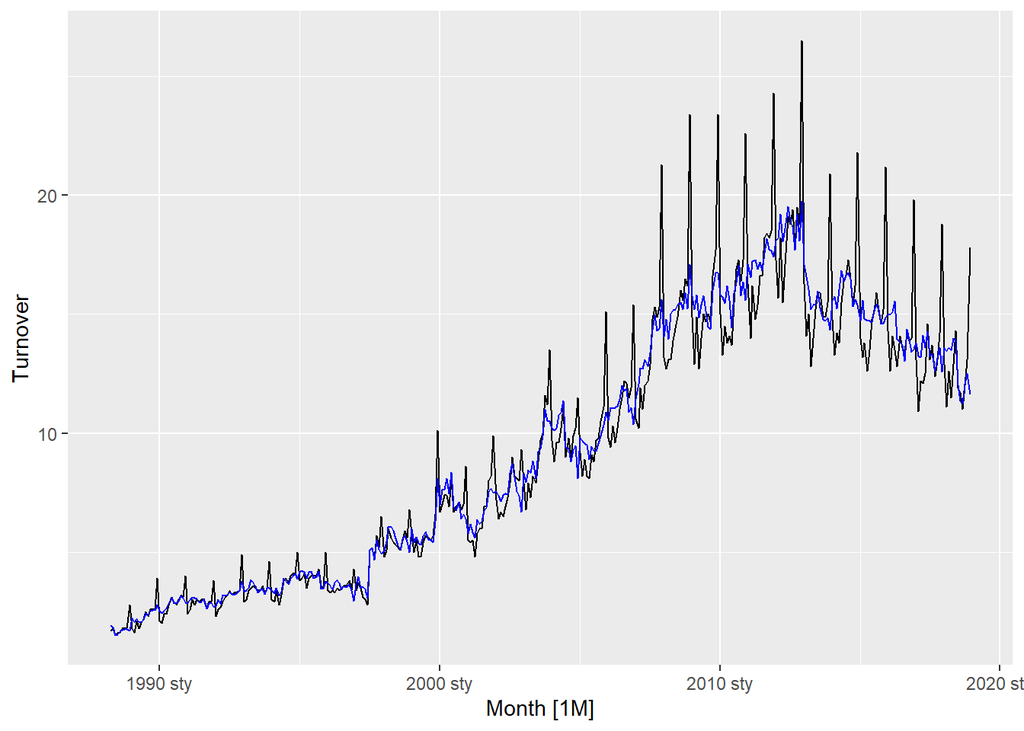

```r
myseries %>% model(STL(Turnover)) %>% components() -> cldc_stl
myseries %>% autoplot() + autolayer(cldc_stl,season_adjust, color="blue")
```

Na wykresie niebieską linią przedstawiono dane skorygowane sezonowo, natomiast linią czarną dane rzeczywiste.

```r
data_adj <- cldc_stl$season_adjust
myseries_adj <- myseries[,c(1,2,3,4)]
myseries_adj$Turnover_adj <- data_adj

myseries_adj %>% filter(year(Month)<=2011) -> train_adj
myseries_adj %>% filter(year(Month)>2011) -> test_adj

train_adj %>% features(Turnover_adj, features = guerrero) -> lambda

lambda_bc <- lambda$lambda_guerrero

fit__bc <- train_adj %>% select(Turnover_adj) %>%
  model(
    ets_box_cox = ETS(box_cox(Turnover_adj,lambda_bc))
  )

ets_acc_train <- accuracy(fit__bc)
fit__bc %>% forecast(h=nrow(test_adj)) -> box_cox_fc
ets_acc_test <- accuracy(box_cox_fc, test_adj)

kbl(rbind(ets_acc_train, ets_acc_test,damped_train,damped_test)) %>%
  kable_styling(bootstrap_options = c("striped", "hover", "bordered", "responsive"))
```

| .model | .type | ME | RMSE | MAE | MPE | MAPE | MASE | RMSSE | ACF1 |
| --- | --- | --- | --- | --- | --- | --- | --- | --- | --- |
| ets_box_cox | Training | 0.0064750 | 0.5110107 | 0.3646967 | -0.3156886 | 5.278883 | 0.3570199 | 0.3798205 | 0.0058015 |
| ets_box_cox | Test | -7.3563903 | 8.7257785 | 7.5067262 | -53.4559594 | 54.243090 | NaN | NaN | 0.9502550 |
| damped | Training | 0.0006624 | 0.0977796 | 0.0713974 | -0.3739238 | 4.782880 | 0.4696223 | 0.5067912 | 0.1609946 |
| damped | Test | -0.1544718 | 0.2100351 | 0.1784139 | -5.9636380 | 6.783834 | NaN | NaN | 0.8931470 |

Powyższe zestawienie błędów prognoz dla modelu Holta-Wintersa z wygaszonym trendem oraz modelu ETS dla danych skorygowanych sezonowo i przekształconych metodą Boxa-Coca pozwala stwierdzić na podstawie błędu MAPE, że model Holta-Wintersa z wygaszonym trendem jest lepszy niż model ETS.

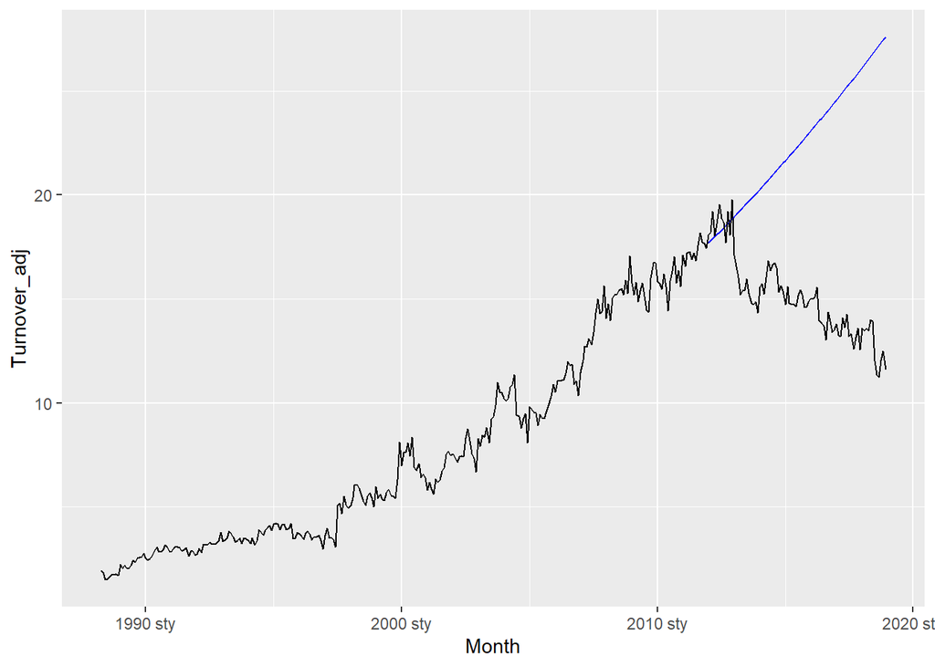

```r
box_cox_fc %>% autoplot(level=NULL) + autolayer(myseries_adj, Turnover_adj, color='black')
```

Wniosek ten został potwierdzony na wykresie, na którym można zaobserwować, że prognoza wykonana za pomoca modelu ETS jest zdecydowanie różna od wartości rzeczywistych. Jedynie w pierwszych kilku miesiącach dobrze odwzorowuje trend, natomiast dla kolejnych miesięcy trend wzrostowy w prognozie utrzumuje się, pomimo że dla danych rzeczywistych jest on juz spadkowy.

## Zadanie V - ARIMA

W kolejnej części projektu wyestymowano model ARIMA. Skrót ten oznacza autoregresyjny zintegrowany model średniej ruchomej. Te modele zatem skłądają się z kilku elementów (procesu AR, procesu MA oraz ze stopnia integracji). Wybrano automatyczną ARIMĘ - na podstawie przekazanego szeregu czasowego, następuje wybór optymalnej postaci modelu (a to wszsytko bez udziału człowieka). Poniżej przedstawiono jego specyfikację:

```r
train %>% model(arima = ARIMA(log(Turnover))) -> train_fit


train_fit %>%
  select(arima) %>%
  report(train_fit)
```

```
## Series: Turnover
## Model: ARIMA(1,0,1)(0,1,1)[12] w/ drift
## Transformation: log(Turnover)
##
## Coefficients:
##          ar1      ma1     sma1  constant
##       0.8619  -0.2320  -0.8432    0.0131
## s.e.  0.0406   0.0797   0.0536    0.0008
##
## sigma^2 estimated as 0.00667:  log likelihood=290.74
## AIC=-571.49   AICc=-571.26   BIC=-553.44
```

Postać modelu SARIMA(1,0,1)(0,1,1)[12] oznacza, że mamy do czynienia z:  
- procesem autoregresyjnym I rzędu - na wartości z danego miesiąca składa się 0.862 wartości z miesiąca poprzedniego  
- brakiem integracji - sugerować to może stacjonarność bazowych danych, ponieważ nie trzeba stoswać przyrostów  
- procesem średniej ruchomym rzędu 1 - przy obliczaniu miesięcznej wartość logarytmu obrotu uwazględniane jest również odchylenie od średniej z poprzedniego okresu (wykorzystywane jest około 20% ich wartości, ponadto pomniejszają one aktualną miesięczną wartość)  
- sezonowością z okresem równym 12 i składową zintegrowaną I stopnia, opisywaną również procesem średniej ruchomej - model poprawnie zakwalifikował dane jako miesięczne, czynnik sezonowy poddano różnicowaniu (zatem bada się różnicę wartości z odpowiadających miesięcy obecnego i poprzedniego roku). Zastosowanie przyrostów w takiej formie wydaje się uzasadnione - sezonowość wiąże się z systematycznymi wahaniami w czasie. Właśnie dzięki przyrostom odpowiadających okresów można przeanalizować nie tylko zmiany w danym mieisącu z roku na rok, lecz również przekazać do modelu informację, jak kształtowała się szukana wartość w danym momencie, aby można było powielić sezonowe zachwoanie. Obecność składowej *sma1* w modelu oznacza, że na bieżącą wartość szeregu czasowego (log(Turnover)) wpływa również czynnik sezonowy, obecny pod postacią odchylenia od wartości średniej przyrostu z okresu sprzed pełnego sezonu (a zatem z poprzedniego roku np. grudnia 2019 dla grudnia 2020). Wartości odchyleń przyrostów oddziałują na wartość bieżącą w sposób przeciwny (znak **-**), prawie całą swoją wartością (współczynnik równy 0.843). W ten sposób prognozowana wartość jest modyfikowana o wartość odchylenia od średniej - im większe ono było (np. dla grudnia, którego wartości wymykają się nawet sezonowej dekompozycji, co zauważyć mozna w II części projektu) tym bardziej w analogicznym miesiąc również będzie odbiegał od średniej.  
Na poniższym rysunku przedstawiono skutek przeprowadzonego prognozowania, za pomocą sezonowej ARIMA’y:

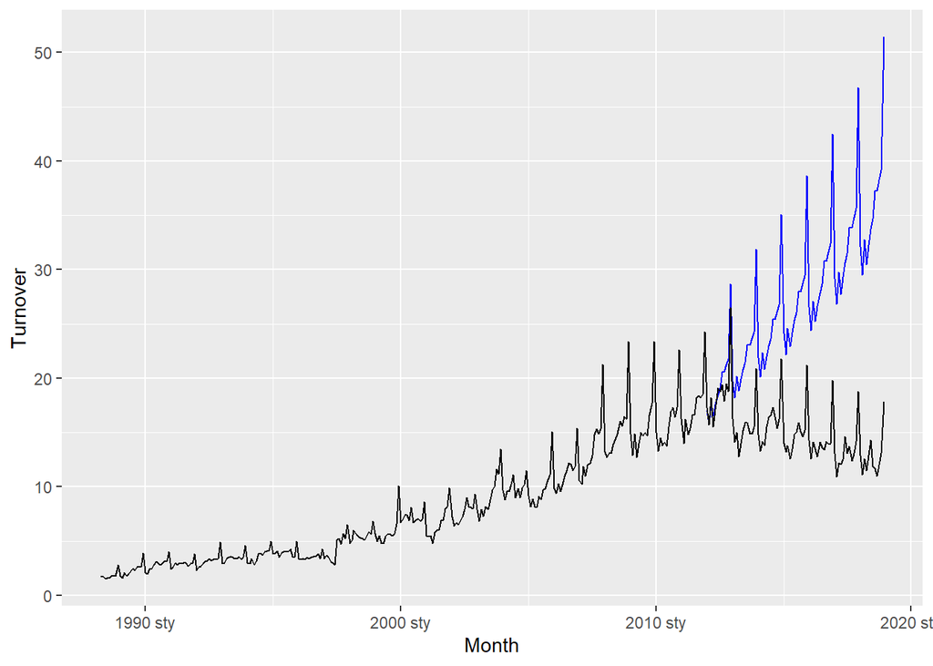

```r
train_fit %>%
  select(arima) %>%
  forecast(h = nrow(test)) ->prognoza
prognoza%>%
  autoplot(level=NULL) + autolayer(myseries,Turnover, color="black")
```

Z powyższego wykresu wynika:

- SARIMA świetnie odwzorowałą sezonowość zmian - w grudniu ciągle wystęują piki obrotu, któRe również stopniowo zwiększają się (tak jak miało to miejsce w danych treningowych)
- Zauważyć mozna jak bardzo punkt podziału danych na zbiór uczący i testowy wpłynął na jakość porgnoz. Model świetnie dostosował się do danych treningowych i odwzorował występującą zależność - pomimo tego błędy prognozy będą ogromne. Wszystko ze względu na wybór daty początkowej danych testowych na moment tuż przed kryzysie finansowym. Początkowe prognozy są dobre, natomiast później w danych zachodzi odwrócenie trendu któergo możliwego wystąpienia nie dało się przewidzieć z danych.
- Prognozy nawet bardziej zaawansowanych modeli jak SARIMA, wyuczonych na setkach obserwacji wciąż nie są w stanie uwzględnić wydarzeń nagłych, na które nie wskazują dane.  
  Poniżej przedstawiono zestawienie błędów prognozy modelu SARIMA:

```r
kbl(accuracy(prognoza, test) ) %>%
  kable_styling(bootstrap_options = c("striped", "hover", "bordered", "responsive"))
```

| .model | .type | ME | RMSE | MAE | MPE | MAPE | MASE | RMSSE | ACF1 |
| --- | --- | --- | --- | --- | --- | --- | --- | --- | --- |
| arima | Test | -12.19777 | 14.36946 | 12.23358 | -87.47773 | 87.67274 | NaN | NaN | 0.8942547 |

Wartości zarówno błędów ME,RMSE, jak i MAE oscylują wokół 12-14 (dla ME jest to wartość ujemna). Należy pamiętać , że wartość ta oznacza miliony AUD, zatem występujący błąd jest znaczny już w podejściu bezwzględnym. Warto również zwrócić uwagę, że nie występują znaczne różnice pomiędzy tymi bezwzględnymi błędami - wynika to z tego, że:  
- błędy były ‘jednostronne’ - zawsze to prognoza była większa iż wartość rzeczywista, zatem błędy nie przyjmowały przeciwnych wartości, a w rezultacie nie pokrywały się wzajemnie (stąd wartość bezwzględna z ME jest zbliżona do MAE)  
- podobieństwo MAE do RMSE oznacza, że w okresie prognozy nie wystąpiły bardzo duże błędy, znacznie odstające od pozostałych - szereg prognoz co prawda ciągle oddalał się od rzeczywistych danych, natomaist były to stopinowe wzrosty, które były odnotowywane przez wszystkie rodzaje błędów (bowiem gdyby wystąpiły znaczące błędy, wartość RMSE byłaby zawyżona - gdyż wykorzystuje on kwadrat błędów, a funkcja kwadratowa jest silnie rosnąca wraz ze wzrostem arguentów). Mogło być to również spowodowane skalą - największe wartości prognozy nie przekroczyły 60, zatem nawet po podniesieniu do kwadratu najwięKszych błędów (rzędu 35) nie otrzymano anomalii.  
- błąd MAPE jest błędem względnym - informuje jaki procent wartości realnej stanowił błąd. Otrzymana wartość (87.7) oznacza, że błąd prognozy SARIMA stanowił prawie 90% prognozowanej wartości - pokazuje to, że otrzymana prognoza jest bardzo niedokładna.

#### Weryfikacja stacjonarności

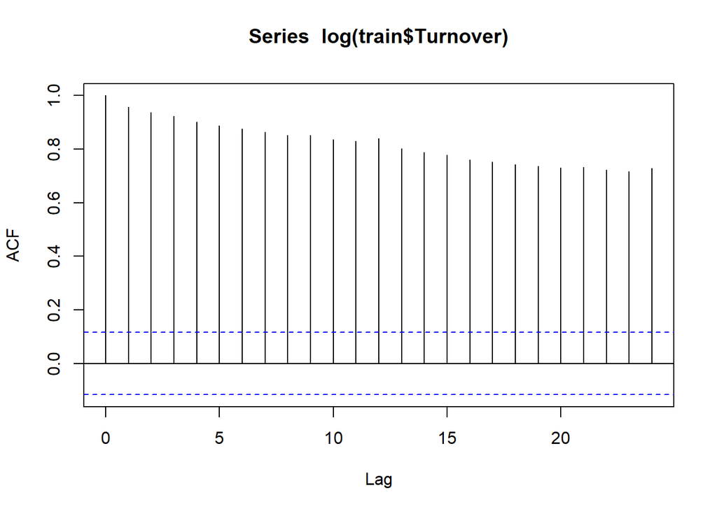

```r
acf(log(train$Turnover),
    type = c("correlation"),
    plot = TRUE)
```

```r
library("tseries")
adf.test(log(train$Turnover))
```

```
##
##  Augmented Dickey-Fuller Test
##
## data:  log(train$Turnover)
## Dickey-Fuller = -5.2239, Lag order = 6, p-value = 0.01
## alternative hypothesis: stationary
```

## Zadanie VI - THETA i NNETAR

W ostatnim kroku zdecydowano się zbudować również prognozy Theta oraz NNETAR (Neural Network Time Series Forecasts) z domyślnymi parametrami.

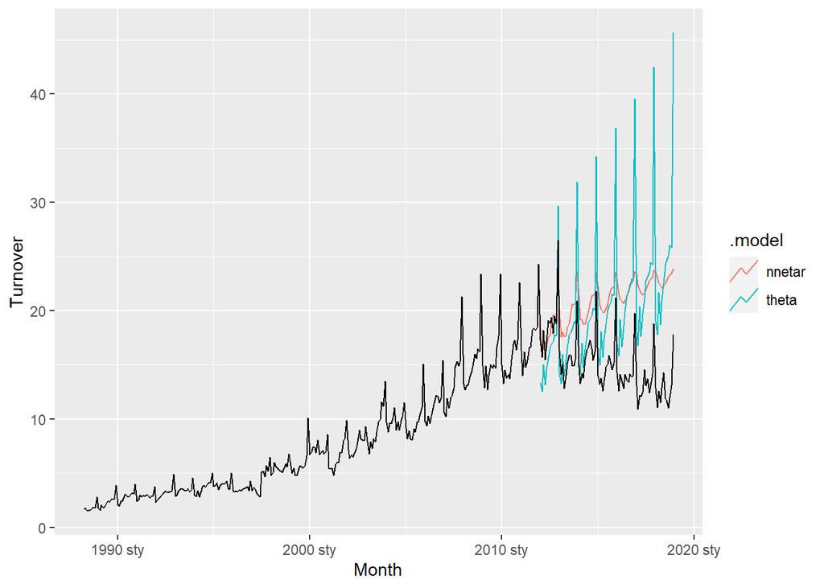

```r
fit6 <- train %>% select(Turnover) %>%
  model(
    theta = THETA(log(Turnover)),
    nnetar = NNETAR(log(Turnover))
  )

fit6_acc_train <- accuracy(fit6)

fc6 <- fit6 %>%
  forecast(h = nrow(test))

fc6 %>% autoplot(level=NULL) + autolayer(myseries,Turnover,color="black")
```

```r
fit6_acc_test <- accuracy(fc6, test)

kbl(rbind(fit6_acc_train, fit6_acc_test)) %>%
  kable_styling(bootstrap_options = c("striped", "hover", "bordered", "responsive"))
```

| .model | .type | ME | RMSE | MAE | MPE | MAPE | MASE | RMSSE | ACF1 |
| --- | --- | --- | --- | --- | --- | --- | --- | --- | --- |
| theta | Training | 0.021783 | 1.0086955 | 0.5823887 | 0.8771208 | 7.320691 | 0.5739788 | 0.7462693 | -0.2413311 |
| nnetar | Training | 0.048498 | 0.8855975 | 0.6206822 | -0.6597634 | 8.660265 | 0.6117192 | 0.6551970 | 0.1689808 |
| nnetar | Test | -5.923265 | 6.9060535 | 6.0955747 | -43.8784705 | 44.705595 | NaN | NaN | 0.7945631 |
| theta | Test | -5.273906 | 7.8536115 | 5.9834316 | -37.1697831 | 41.229790 | NaN | NaN | 0.5697369 |

## Podsumowanie

Logarytm okazał się skutecznym sposobem stabiiizacji wariancji dla szeregu wartości miesięcznego obrotu urządzeń elektrycznych i elektronicznych. Dane te charakteryzowały się trendem, sezonowością oraz cyklicznością. Klasyczna metoda dekompozycji lepiej sprawdziła się w odsezonowieniu niż metoda STL. Spośród metod benchmarkingowych najlepsza okazała się metoda SNAIVE (osiągała ona jedne z mniejszych błędów MAPE dla danych treningowych, a także najlepsze wyniki podczas prognozy na zbiorze testowym - wynoszący **27.4**). Najgorszą metodą była metoda dryftu (MAPE = **374.1**), gdyż zupełnie nie dostoowała się ona do odwrócenia trendu w danych testowych - przebieg rozpatrywanego szeregu czasowego stanowił bowiem duże wyzwanie dla większości metod prognozowania (ze względu na stały trend wzrostowy w danych treningowych i nagły spadek obrotu po zaledwie kilku mieisącach ze zbioru testowego - modele wyuczyły się wzrostu zjawiska i nie potrafiły odwzorować nagłej zmiany). Warto zwrócić przy tym uwagę na wysoką skuteczność dryftu dla danych treningowych - nie zawsze bowiem takie zjawisko gwarantuje powtórzenie trafności dla nowych danych. Z rodziny modeli ETS najbardziej trafna była prognoza metodą Holta-Wintersa z wygaszonym trendem (MAPE = **6.8**) - ponieważ właśnie wygaszenie trendu dobrze odwzorowało skutek kryzysu gospodarczego i wiążący się z nim spadek obrotu. Nie oznacza to natomiast, że model ten będzie uniwersalny do każdych danych - sprawdzić się może natomiast, gdy w szeregu czasowym doszło do odwrócenia trendu wzrostowego. Wykorzystana w kolejnym etapie SARIMA charakteryzowałą się ponad 12-krotnie większą wartością błędu MAPE (**87.7**) - model ten również wyuczył się tendencji wzrostowej, przez co prognoza dla danych testowych była nietrafiona. Natomiast wykorzystane do jego uczenia dane okazały się stacjonarne. Mniejszymi błędami charakteryzowały się metody THETA oraz NNETAR - natomiast nawet wykorzystanie sieci neuronowej w drugiej z nich nie przyczyniło się do uzyskania lepszych wyników niż benchmarkingowa metoda SNAIVE (odpowiednio **41.2** i **44.7**).